# A/B 测试：营销广告对用户转化率的效果评估

**项目类型**：独立完成的 A/B 测试分析项目  
**数据来源**：Kaggle Marketing A/B Testing Dataset  
**数据量**：588,101 条用户记录  
**分析时间**：2026年5月

## 🎯 项目背景与业务问题

某电商平台进行了一次广告投放实验，将用户随机分为两组：

- **实验组（ad）**：看到商业推广广告
- **对照组（psa）**：看到公益广告（安慰剂）

**核心业务问题**：商业广告是否真的能提升用户购买转化率？如果能，效果有多大？在什么时间投放效果最好？

```python
# === 基础数据处理与可视化 ===
import pandas as pd
import numpy as np
import matplotlib.pyplot as plt

# === 统计检验与建模 ===
import statsmodels.api as sm
from statsmodels.stats.proportion import proportions_ztest
from statsmodels.stats.multitest import multipletests
from scipy.stats import chi2_contingency, norm

# === 机器学习 ===
from sklearn.linear_model import LogisticRegression
```

```python
# 设置中文字体（以黑体为例，Windows 可用 SimHei，macOS 可用 'Arial Unicode MS'）
plt.rcParams['font.sans-serif'] = ['SimHei']  # 或 ['Microsoft YaHei']、['WenQuanYi Zen Hei']
plt.rcParams['axes.unicode_minus'] = False   # 解决负号显示异常
```

```python
#读取数据。发现有索引列，直接引用
df = pd.read_csv('D:/myproject/data/marketing_AB.csv', index_col=0)
```

## 📐 实验设计

本分析为事后分析（Post-hoc Analysis），数据已全部收集完成。我们基于实际数据，验证实验功效是否充足。

| 参数 | 数值 | 来源 |
| --- | --- | --- |
| 对照组实际转化率 | 1.79% | 从数据中计算得出 |
| 最小可检测效应 (MDE) | 1 个百分点 | 业务决策阈值 |
| 显著性水平 (α) | 0.05 | 行业标准 |
| 统计功效 (1-β) | 0.80 | 行业标准 |

```python
# ==================== 实验设计 ====================
alpha = 0.05           # 显著性水平
power = 0.80           # 功效
mde = 0.01             # 最小可检测效应（1个百分点）

# 用真实的对照组转化率作为基线（实验后验证，不再假设）
baseline_cr = df[df['test group'] == 'psa']['converted'].mean()

# 单尾检验对应的 Z 值
z_alpha = norm.ppf(1 - alpha)   # 约 1.645
z_beta  = norm.ppf(power)       # 约 0.842

# 预期实验组转化率（对照组 + 我们想检测的最小提升）
p1 = baseline_cr + mde
p2 = baseline_cr

# 两组合并比例（用于零假设下的方差估计）
p_bar = (p1 + p2) / 2

# 精确样本量公式
numerator = (z_alpha * np.sqrt(p1*(1-p1) + p2*(1-p2)) +
             z_beta  * np.sqrt(2 * p_bar * (1 - p_bar)))**2
denominator = (p1 - p2)**2

n_per_group = numerator / denominator

# 实际各组样本量
n_ad = df[df['test group'] == 'ad'].shape[0]
n_psa = df[df['test group'] == 'psa'].shape[0]
```

## 🔬 主效应检验：广告是否显著提升了转化率？

### 假设设定

- **H₀**：CR(ad) = CR(psa) （广告无效）
- **H₁**：CR(ad) > CR(psa) （广告有效，单尾检验）

### 分析方法

- **两样本比例 Z 检验**（单尾）
- **Bootstrap 稳健性检验**（10,000 次重抽样）

### 核心结果

| 指标 | 数值 |
| --- | --- |
| 广告组转化率 | 2.55% |
| 对照组转化率 | 1.79% |
| **绝对提升** | **0.77%** |
| **相对提升** | **43.09%** |
| Z 统计量 | 7.37 |
| P 值 | < 0.001 |
| Bootstrap 95% CI | [0.59%, 0.94%] |

### 结论

✅ **拒绝 H₀**。商业广告对提升购买转化率有真实、显著的效果，提升约 0.77 个百分点（相对提升 43%）。Bootstrap 95% 置信区间完全在 0 的上方，结论稳健。

```python
# ==================== 主假设检验：广告是否显著提升了转化率？ ====================

# 1. 数据准备：将布尔值转化为 0 和 1 的数值
#    原理：True/False 变成 1/0，求均值就得到了转化率
df['conversion'] = df['converted'].astype(int)

# 2. 分别提取实验组和对照组的转化数据
ad_conv = df[df['test group'] == 'ad']['conversion']      # 实验组，所有看到商业广告的用户
psa_conv = df[df['test group'] == 'psa']['conversion']    # 对照组，所有看到公益广告的用户

# 3. 计算并对比两组转化率
cr_ad = ad_conv.mean()    # 实验组转化率 (mean of 0/1 = proportion of 1's)
cr_psa = psa_conv.mean()  # 对照组转化率
lift_abs = cr_ad - cr_psa              # 绝对提升量
lift_rel = (lift_abs / cr_psa) * 100   # 相对提升百分比

# 4. 主假设检验：两样本比例 Z 检验 (单尾)
#    H₀: CR_ad = CR_psa  (广告无效)
#    H₁: CR_ad > CR_psa  (广告有效)
#    alternative='larger' 表示单尾检验

count_ad = ad_conv.sum()   # 实验组购买人数
n_ad = len(ad_conv)        # 实验组总人数
count_psa = psa_conv.sum() # 对照组购买人数
n_psa = len(psa_conv)      # 对照组总人数

z_stat, p_value = proportions_ztest(
    count=[count_ad, count_psa],
    nobs=[n_ad, n_psa],
    alternative='larger'   # 因为我们的备择假设是 ad > psa
)

alpha = 0.05  # 我们设定的显著性水平

# 5. Bootstrap 稳健性检验 (补充验证)
#    目的：不依赖正态假设，用重抽样方法直接估计提升量的 95% 置信区间

np.random.seed(42)  # 设置随机种子，保证结果可复现

def bootstrap_diff(data1, data2, n_iter=10000):
    """
    用 Bootstrap 方法计算两组均值差的 95% 置信区间
    data1: 实验组数据 (0/1数组)
    data2: 对照组数据 (0/1数组)
    n_iter: 重抽样次数
    """
    diffs = []
    n1, n2 = len(data1), len(data2)
    for _ in range(n_iter):
        # 有放回地随机抽样，样本量与原始组相同
        sample1 = np.random.choice(data1, size=n1, replace=True)
        sample2 = np.random.choice(data2, size=n2, replace=True)
        diff = sample1.mean() - sample2.mean()
        diffs.append(diff)
    # 取 2.5% 和 97.5% 分位数作为 95% 置信区间
    return np.percentile(diffs, [2.5, 97.5])

boot_ci = bootstrap_diff(ad_conv.values, psa_conv.values)
```

## 📅 每日分析：广告效果是否因星期几而异？

### 分析方法

1. **每日卡方独立性检验**：对一周的每一天，检验广告类型与购买行为是否独立。
2. **FDR-BH 多重检验校正**：控制 7 次检验的整体错误发现率。
3. **交互效应检验**：用逻辑回归 + 似然比检验，判断星期几是否调节了广告效果。

### 核心结果

| 星期 | 绝对提升（百分点） | 校正后 P 值 | 是否显著 |
| --- | --- | --- | --- |
| Tuesday | 1.60 | < 0.001 | ✅ |
| Monday | 1.07 | 0.0014 | ✅ |
| Wednesday | 0.96 | 0.0014 | ✅ |
| Saturday | 0.73 | 0.0159 | ✅ |
| Friday | 0.62 | 0.0190 | ✅ |
| Sunday | 0.40 | 0.2046 | ❌ |
| Thursday | 0.14 | 0.5932 | ❌ |

**交互效应检验**：似然比统计量 = 4.03，P = 0.045 ✅ 存在显著的交互效应。

### 结论

```python
# ==================== 第 1 小步：每日卡方独立性检验 ====================

days = ['Monday', 'Tuesday', 'Wednesday', 'Thursday', 'Friday', 'Saturday', 'Sunday']
daily_results = []

for day in days:
    # 筛选该天的数据
    day_data = df[df['most ads day'] == day]

    # 构建 2×2 列联表（广告类型 × 是否购买）
    contingency = pd.crosstab(
        day_data['test group'],
        day_data['converted'],
        margins=False
    )

    # 卡方独立性检验
    chi2, p_val, dof, expected = chi2_contingency(contingency)

    # 计算该天两组的转化率
    cr_ad_day = day_data[day_data['test group'] == 'ad']['converted'].mean()
    cr_psa_day = day_data[day_data['test group'] == 'psa']['converted'].mean()
    lift_day = cr_ad_day - cr_psa_day

    daily_results.append({
        '星期': day,
        '广告组转化率': cr_ad_day,
        '对照组转化率': cr_psa_day,
        '绝对提升': lift_day,
        '卡方统计量': chi2,
        'P值': p_val
    })

daily_df = pd.DataFrame(daily_results)
print("每日卡方独立性检验结果（未校正）：")
display(daily_df.round(4))
```

```
每日卡方独立性检验结果（未校正）：
```

|  | 星期 | 广告组转化率 | 对照组转化率 | 绝对提升 | 卡方统计量 | P值 |
| --- | --- | --- | --- | --- | --- | --- |
| 0 | Monday | 0.0332 | 0.0226 | 0.0107 | 11.7525 | 0.0006 |
| 1 | Tuesday | 0.0304 | 0.0144 | 0.0160 | 24.1692 | 0.0000 |
| 2 | Wednesday | 0.0254 | 0.0158 | 0.0096 | 12.2543 | 0.0005 |
| 3 | Thursday | 0.0216 | 0.0202 | 0.0014 | 0.2854 | 0.5932 |
| 4 | Friday | 0.0225 | 0.0163 | 0.0062 | 6.0952 | 0.0136 |
| 5 | Saturday | 0.0213 | 0.0140 | 0.0073 | 6.8026 | 0.0091 |
| 6 | Sunday | 0.0246 | 0.0206 | 0.0040 | 1.8361 | 0.1754 |

以上是未校正的每日P值。由于同时做了7次检验，我们需要用FDR-BH方法校正，控制整体错误发现率。

```python
# ==================== 第 2 小步：FDR-BH 多重检验校正 ====================

p_values_uncorrected = daily_df['P值'].values
rejected, p_values_corrected, _, _ = multipletests(
    p_values_uncorrected,
    alpha=0.05,
    method='fdr_bh'           # Benjamini-Hochberg 方法
)

daily_df['校正后P值'] = p_values_corrected
daily_df['是否显著（校正后）'] = rejected

print("\nFDR-BH 校正后结果：")
display(daily_df[['星期', '绝对提升', 'P值', '校正后P值', '是否显著（校正后）']].round(4))

# 找出显著的天
significant_days = daily_df[daily_df['是否显著（校正后）'] == True]['星期'].tolist()
if significant_days:
    print(f"\n广告效果显著的天（校正后）：{', '.join(significant_days)}")
else:
    print("\n校正后没有天显示广告效果显著。")
```

```
FDR-BH 校正后结果：
```

|  | 星期 | 绝对提升 | P值 | 校正后P值 | 是否显著（校正后） |
| --- | --- | --- | --- | --- | --- |
| 0 | Monday | 0.0107 | 0.0006 | 0.0014 | True |
| 1 | Tuesday | 0.0160 | 0.0000 | 0.0000 | True |
| 2 | Wednesday | 0.0096 | 0.0005 | 0.0014 | True |
| 3 | Thursday | 0.0014 | 0.5932 | 0.5932 | False |
| 4 | Friday | 0.0062 | 0.0136 | 0.0190 | True |
| 5 | Saturday | 0.0073 | 0.0091 | 0.0159 | True |
| 6 | Sunday | 0.0040 | 0.1754 | 0.2046 | False |

```
广告效果显著的天（校正后）：Monday, Tuesday, Wednesday, Friday, Saturday
```

每日独立检验配合FDR校正可以找出哪些天效果显著，但无法整体判断"星期几是否调节了广告效果"。我们用逻辑回归+似然比检验来做整体验证。

```python
# ==================== 第 3 小步：交互效应检验 ====================

# 准备数据：创建数值变量
df_temp = df.copy()
df_temp['is_ad'] = (df_temp['test group'] == 'ad').astype(int)  # 广告类型（0/1）
df_temp['day_num'] = df_temp['most ads day'].map({
    'Monday': 0, 'Tuesday': 1, 'Wednesday': 2,
    'Thursday': 3, 'Friday': 4, 'Saturday': 5, 'Sunday': 6
})

# 模型 1：无交互项（只有主效应）

X_no_interact = sm.add_constant(df_temp[['is_ad', 'day_num']])
y = df_temp['converted']
model_no_interact = sm.Logit(y, X_no_interact).fit(disp=0)

# 模型 2：有交互项（广告类型 × 星期几）
df_temp['ad_x_day'] = df_temp['is_ad'] * df_temp['day_num']
X_with_interact = sm.add_constant(df_temp[['is_ad', 'day_num', 'ad_x_day']])
model_with_interact = sm.Logit(y, X_with_interact).fit(disp=0)

# 似然比检验：比较两个模型
from scipy.stats import chi2
lr_stat = 2 * (model_with_interact.llf - model_no_interact.llf)
lr_p = 1 - chi2.cdf(lr_stat, df=1)  # 交互项只有1个自由度
```

## ⏰ 逐时分析：哪个时段转化率最高？

### 分析方法

- 筛选广告效果显著的日期（周一、二、三、五、六）。
- 用逻辑回归建模：转化概率 ~ 小时（作为分类变量）。
- 输出每个小时广告组的预测转化概率并排序。

### 核心结果

| 排名 | 时段 | 预测转化率 |
| --- | --- | --- |
| 🥇 | 15:00 | 3.23% |
| 🥈 | 16:00 | 3.21% |
| 🥉 | 14:00 | 3.09% |
| ... | ... | ... |
| 22 | 1:00 | 1.29% |
| 23 | 2:00 | 0.96% |

```python
# 1. 筛选有效日期（校正后显著的天）
significant_days = ['Monday', 'Tuesday', 'Wednesday', 'Friday', 'Saturday']
df_effective = df[df['most ads day'].isin(significant_days)]

# 2. 只取广告组数据（因为我们要预测广告组内的转化概率）
df_ad = df_effective[df_effective['test group'] == 'ad'].copy()

# 3. 构建逻辑回归模型
#   把小时作为分类变量（独热编码），以捕捉不同时段的非线性效应
hour_dummies = pd.get_dummies(df_ad['most ads hour'], prefix='hour')
X = hour_dummies
y = df_ad['converted']

model = LogisticRegression(max_iter=1000)
model.fit(X, y)

# 4. 预测每小时广告组的转化概率
#   构造一个包含所有小时（0-23）的预测数据集
hour_range = list(range(24))
hour_predict_data = pd.DataFrame([
    [1 if h == hour else 0 for hour in range(24)]
    for h in hour_range
], columns=hour_dummies.columns)

predicted_probs = model.predict_proba(hour_predict_data)[:, 1]

# 5. 整理结果并排序
hourly_results = pd.DataFrame({
    '小时': hour_range,
    '预测转化率': predicted_probs
}).sort_values('预测转化率', ascending=False)

print("各小时广告组预测转化率排名：")
display(hourly_results.style.format({'预测转化率': '{:.4%}'}))
```

```
各小时广告组预测转化率排名：
```

|  | 小时 | 预测转化率 |
| --- | --- | --- |
| 15 | 15 | 3.2279% |
| 16 | 16 | 3.2130% |
| 14 | 14 | 3.0888% |
| 21 | 21 | 2.9615% |
| 17 | 17 | 2.9215% |
| 20 | 20 | 2.8437% |
| 18 | 18 | 2.8085% |
| 22 | 22 | 2.6994% |
| 13 | 13 | 2.6985% |
| 19 | 19 | 2.5869% |
| 12 | 12 | 2.5619% |
| 5 | 5 | 2.4783% |
| 6 | 6 | 2.4709% |
| 10 | 10 | 2.3901% |
| 11 | 11 | 2.3640% |
| 4 | 4 | 2.2922% |
| 9 | 9 | 2.1021% |
| 23 | 23 | 2.0834% |
| 8 | 8 | 1.9300% |
| 0 | 0 | 1.6938% |
| 7 | 7 | 1.6527% |
| 3 | 3 | 1.5626% |
| 1 | 1 | 1.2913% |
| 2 | 2 | 0.9600% |

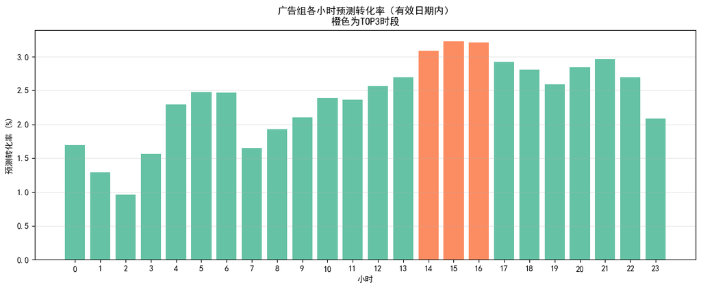

```
转化率最高的3个时段：
  15:00 - 预测转化率 3.2279%
  16:00 - 预测转化率 3.2130%
  14:00 - 预测转化率 3.0888%
```

```python
# 6. 可视化
import matplotlib.pyplot as plt

plt.figure(figsize=(12, 5))
colors = ['#fc8d62' if hour in hourly_results.head(3)['小时'].values else '#66c2a5'
          for hour in hourly_results['小时']]
plt.bar(hourly_results['小时'], hourly_results['预测转化率'] * 100, color=colors)
plt.xlabel('小时')
plt.ylabel('预测转化率 (%)')
plt.title('广告组各小时预测转化率（有效日期内）\n橙色为TOP3时段')
plt.xticks(range(0, 24))
plt.grid(axis='y', alpha=0.3)
plt.tight_layout()
plt.show()

# 输出TOP3时段
print("\n转化率最高的3个时段：")
for _, row in hourly_results.head(3).iterrows():
    print(f"  {int(row['小时'])}:00 - 预测转化率 {row['预测转化率']:.4%}")
```

## ⚠️ 局限性与改进方向

1. **数据缺失**：数据集缺少次要指标（如客单价）和护栏指标（如总营收、卸载率），无法全面评估广告对业务健康度的影响。
2. **时间范围未知**：数据未标注具体日期，无法判断是否包含节假日、促销等特殊事件。
3. **广告频次未深入**：`total ads` 字段显示用户看到的广告次数不同，但本次分析未将其作为控制变量。后续可引入广告频次分组，检验是否存在“过度曝光”导致边际效果递减。
4. **交互效应偏弱**：似然比检验 P = 0.045，接近 0.05 阈值，建议在更大数据集上复现验证。
5. **未做 A/A 测试**：无法完全排除随机化失败的可能性。后续实验应加入 A/A 测试作为对照验证。

如果未来能获取更多字段（金额、用户画像、渠道来源），可进一步构建用户分群模型，并设计更精细的 A/B 测试。

## 💼 从实验到决策：分析结果的业务落地思考

尽管本次A/B测试在统计上得出了广告效果显著的结论，但从分析结果到真正的业务决策，仍存在以下需要审慎评估的鸿沟：

### 1. 广告效果的长期衰减与竞争抹平

本实验仅比较了商业广告与公益广告的短期效果差异，未考虑真实市场环境中，竞品可能同步调整投放策略，导致本平台的广告优势被竞争抹平。此外，用户对同一广告素材的新鲜感会随时间衰减，短期显著的效果不一定能长期维持。建议后续进行长期跟踪实验，观察效果的时间衰减曲线。

### 2. 用户异质性与目标人群匹配

本分析将全体用户视为同质群体，未进行人群细分。广告的实际效果可能集中于某类用户（如价格敏感型），而对高价值用户无效甚至产生负面效果。如果有效果的用户并非平台的目标客群，广告投放的ROI将大打折扣。后续应补充用户分层分析，按消费能力、活跃度等维度评估广告对不同群体的效果差异。

### 3. 转化率到实际收益的漏斗损耗

本实验的核心指标是“观看广告后的购买转化率”，它衡量的是获客环节的效率。但从用户点击购买到最终完成支付、收货、复购，中间还存在支付流失、退换货、履约体验等多个环节。转化率提升不等同于最终利润提升。若要完整评估广告的商业价值，需要打通从曝光到复购的全链路数据，并结合广告投放成本进行ROI测算。